# Processing and Data Exploration

# Further Exploratory Analysis: Covariates

From the first scatterplot, we see that there seems to be a positive association between median household income and vaccination rate. As median household income increases, percent vaccinated increases. This is opposite with poverty rate. As poverty rate increases, percent vaccinated decreases. Regarding unemployment, there is a slight positive association with percent vaccinated. Based the on box plots stratifed by locality, we see that counties labeled as metro have a higher median vaccination rate compared with those labeled as non-metro.

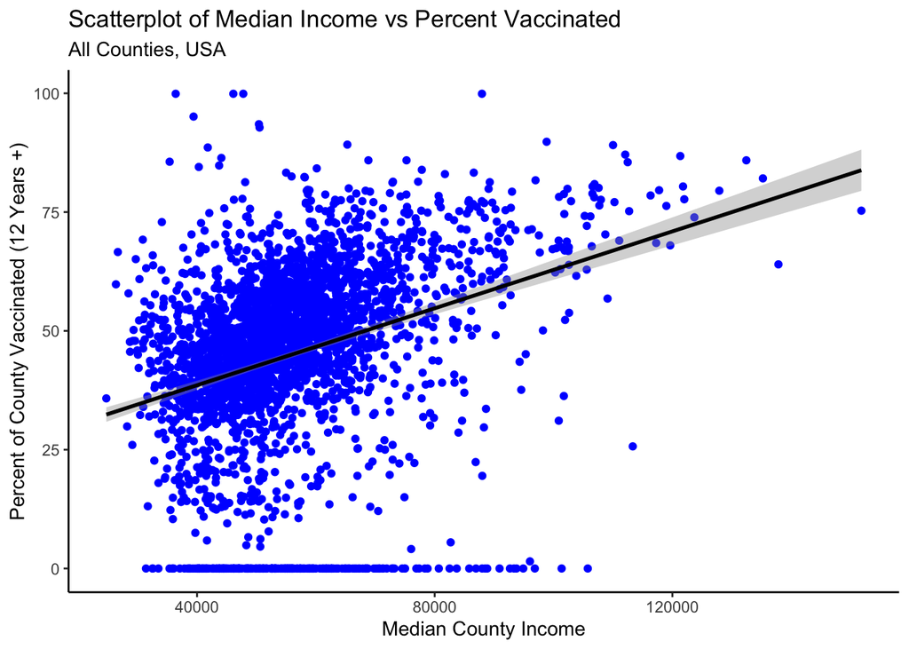

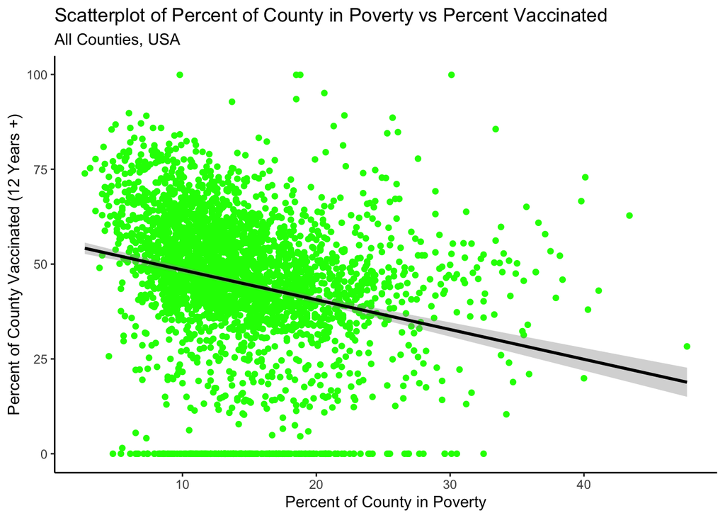

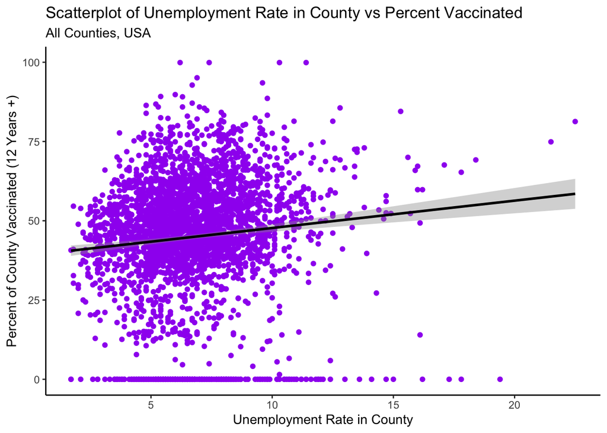

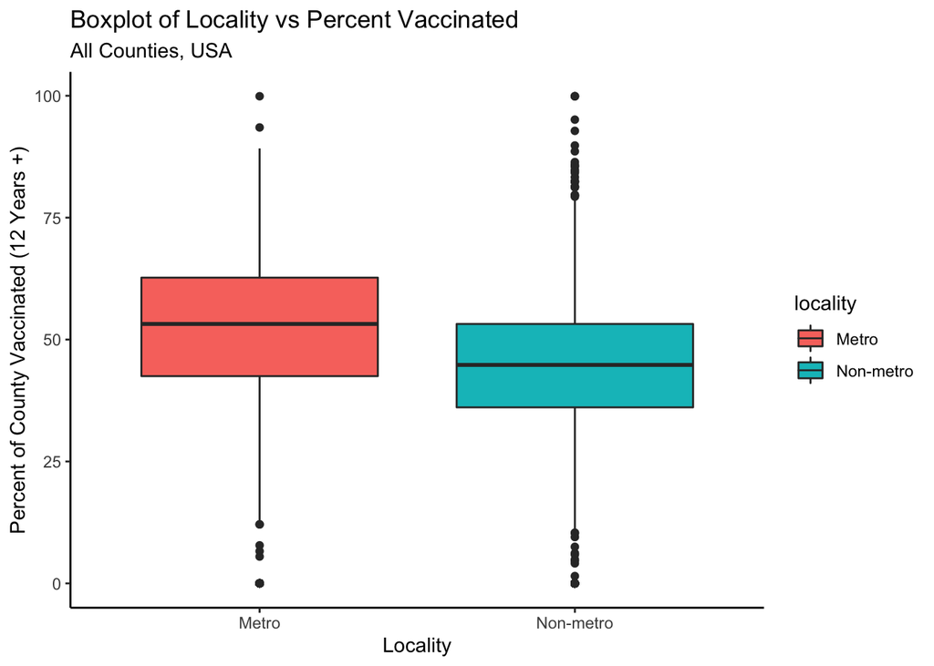

# Tabling Percent Vaccinated by Locality

```r
#define quantiles of interest
q = c(.25, .75)

#calculate quantiles by grouping variable
locality_table <- complete %>%
  group_by(locality) %>%
  summarize(median = round(median(pct_vax, na.rm=TRUE), 1),
            quant25 = round(quantile(pct_vax, probs = q[1], na.rm=TRUE), 1),
            quant75 = round(quantile(pct_vax, probs = q[2], na.rm= TRUE), 1))



#i also combine the 25th percentile and 75th into a character string seperated by a "-"
locality_table$IQR <- paste(locality_table$quant25, locality_table$quant75, sep = "-")

#then i add parentheses around it using this function
addparentheses <- function(x){paste("(", x, ")")}
locality_table$IQR <- addparentheses(locality_table$IQR)


# we don't need the first row or middle colums so we delete them
locality_table <- locality_table[-c(3), -c(3,4)]

names(locality_table)[1] <- "Locality"
names(locality_table)[2] <- "Median Vaccination Rate (%)"

locality_table
```

```
## # A tibble: 2 × 3
##   Locality  `Median Vaccination Rate (%)` IQR
##   <chr>                             <dbl> <chr>
## 1 Metro                              53.2 ( 42.5-62.7 )
## 2 Non-metro                          44.8 ( 36.1-53.2 )
```

```r
#this table might end up in the final paper so saved it as a file
summarytable_file2 = here("results", "summarytable2.rds")
saveRDS(locality_table, file = summarytable_file2)
```

Now I display the saved file for an improved aesthetic.

| Locality | Median Vaccination Rate (%) | IQR |
| --- | --- | --- |
| Metro | 53.2 | ( 42.5-62.7 ) |
| Non-metro | 44.8 | ( 36.1-53.2 ) |

## Mapping:

Finally, I use the usmap package to produce a figure that represents vaccination rates for each county. Here we can see that the largest cluster of counties with low vaccination rates is in Texas and takes up most of the states surface area.

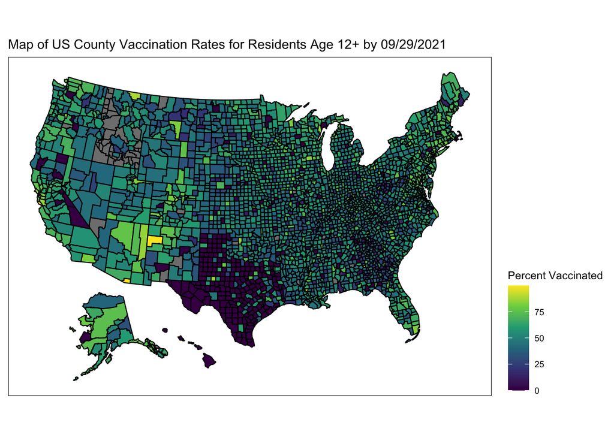

```r
practice <- plot_usmap(regions = "counties") +
  labs(title = "US Counties",
       subtitle = "This is a blank map of the counties of the United States.") +
  theme(panel.background = element_rect(color = "black", fill = "lightblue"))

#here we see that the countypop is a built in dataset within R. we use this below to merge with our dataset.
map <- merge(countypop, complete)

#then we use this new dataset to plot
mapplot <- plot_usmap(data = map, values = "pct_vax") +
  scale_fill_continuous(name = "Percent Vaccinated", label = scales::comma, type = "viridis") + theme(legend.position = "right")

#adding a title and theme adjustment
mapplot + ggtitle("Map of US County Vaccination Rates for Residents Age 12+ by 09/29/2021") +
  theme(panel.background = element_rect(color = "black", fill = "white"))
```

```r
#I think this figure might end up in the final paper so I am going to save it as a PNG...
figure_file = here("results","resultfigure2.png")
ggsave(filename = figure_file, plot=mapplot)
```

Finally, we save our dataset to the processed_data folder below for future analysis.

```r
# location to save file
save_data_location <- here::here("data","processed_data","processeddata.rds")

saveRDS(complete, file = save_data_location)
```